# D2SC ICMA notebook

Madison Chin

2024-10-30

#ICMA Sept 9 2024

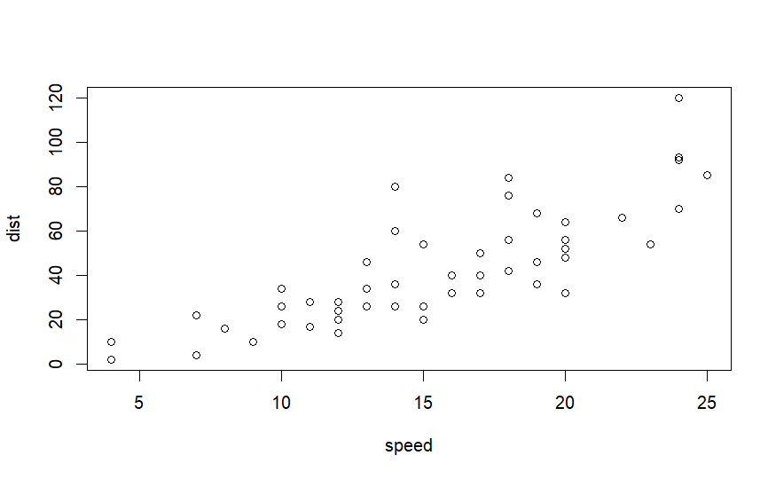

```r
#The downloaded binary packages are in
#C:\Users\mchin\AppData\Local\Temp\RtmpW0fCpq\downloaded_packages
plot(cars)
```

#ICMA Sept 11 2024

```r
ohno_this_is_a_nightmare <- "hello"
```

```r
2+2
```

```
[1] 4
```

```r
x <- 2+2
```

```r
?mean
#how we can look for things we don't know.(use ?)
#function call looks like mean()
#arrays look like c(2,3,4)
```

```r
sd(1:2) ^ 2
```

```
[1] 0.5
```

#ICMA Sept 16 2024

```r
#make sure to complete first code chunks
# to create a vector, use c(list, numbers, inside, like, this)
my_numbers <- c( 1,2,3,4,5,8,9,10)
```

```r
library(magrittr)
library(tidyverse)
#must be loaded each session
```

```r
mean(my_numbers)
```

```
[1] 5.25
```

```r
my_numbers %>%
  mean()
```

```
[1] 5.25
```

```r
getwd()
```

```
[1] "C:/Users/mchin/OneDrive/Documents/GitHub/ADV-Topics-2---DSR-w-R/ICMAs"
```

```r
?mtcars
mtcars
```

|  | mpg | cyl | disp | hp | drat | wt | qsec | vs | am | gear | carb |
| --- | --- | --- | --- | --- | --- | --- | --- | --- | --- | --- | --- |
| Mazda RX4 | 21.0 | 6 | 160.0 | 110 | 3.90 | 2.620 | 16.46 | 0 | 1 | 4 | 4 |
| Mazda RX4 Wag | 21.0 | 6 | 160.0 | 110 | 3.90 | 2.875 | 17.02 | 0 | 1 | 4 | 4 |
| Datsun 710 | 22.8 | 4 | 108.0 | 93 | 3.85 | 2.320 | 18.61 | 1 | 1 | 4 | 1 |
| Hornet 4 Drive | 21.4 | 6 | 258.0 | 110 | 3.08 | 3.215 | 19.44 | 1 | 0 | 3 | 1 |
| Hornet Sportabout | 18.7 | 8 | 360.0 | 175 | 3.15 | 3.440 | 17.02 | 0 | 0 | 3 | 2 |
| Valiant | 18.1 | 6 | 225.0 | 105 | 2.76 | 3.460 | 20.22 | 1 | 0 | 3 | 1 |
| Duster 360 | 14.3 | 8 | 360.0 | 245 | 3.21 | 3.570 | 15.84 | 0 | 0 | 3 | 4 |
| Merc 240D | 24.4 | 4 | 146.7 | 62 | 3.69 | 3.190 | 20.00 | 1 | 0 | 4 | 2 |
| Merc 230 | 22.8 | 4 | 140.8 | 95 | 3.92 | 3.150 | 22.90 | 1 | 0 | 4 | 2 |
| Merc 280 | 19.2 | 6 | 167.6 | 123 | 3.92 | 3.440 | 18.30 | 1 | 0 | 4 | 4 |

[output cut: 22 more lines]

```r
NA
```

```r
write_csv(mtcars, # object name,
         "mtcars_fromR.csv" #file name to save it"
         )
#utils is BaseR, but we want to use the _ version, as it is a part of the tidyverse pkg.
#is wihout rowname implementation and use of "rowtoname function"
```

```r
read_csv("mtcars_fromR.csv")
```

| mpg | cyl | disp | hp | drat | wt | qsec | vs | am | gear | carb |
| --- | --- | --- | --- | --- | --- | --- | --- | --- | --- | --- |
| 21.0 | 6 | 160.0 | 110 | 3.90 | 2.620 | 16.46 | 0 | 1 | 4 | 4 |
| 21.0 | 6 | 160.0 | 110 | 3.90 | 2.875 | 17.02 | 0 | 1 | 4 | 4 |
| 22.8 | 4 | 108.0 | 93 | 3.85 | 2.320 | 18.61 | 1 | 1 | 4 | 1 |
| 21.4 | 6 | 258.0 | 110 | 3.08 | 3.215 | 19.44 | 1 | 0 | 3 | 1 |
| 18.7 | 8 | 360.0 | 175 | 3.15 | 3.440 | 17.02 | 0 | 0 | 3 | 2 |
| 18.1 | 6 | 225.0 | 105 | 2.76 | 3.460 | 20.22 | 1 | 0 | 3 | 1 |
| 14.3 | 8 | 360.0 | 245 | 3.21 | 3.570 | 15.84 | 0 | 0 | 3 | 4 |
| 24.4 | 4 | 146.7 | 62 | 3.69 | 3.190 | 20.00 | 1 | 0 | 4 | 2 |
| 22.8 | 4 | 140.8 | 95 | 3.92 | 3.150 | 22.90 | 1 | 0 | 4 | 2 |
| 19.2 | 6 | 167.6 | 123 | 3.92 | 3.440 | 18.30 | 1 | 0 | 4 | 4 |

[output cut: 22 more lines]

#ICMA Sept 18 2024

```r
?ChickWeight
glimpse(ChickWeight)
```

```
Rows: 578
Columns: 4
$ weight <dbl> 42, 51, 59, 64, 76, 93, 106, 125, 149, 171, 199, 205, 40, 49, 58, 72, 84, 103, 122, 138, 162, 187, 209, 215, 43, 39, 55, 67, 84, 99, …
$ Time   <dbl> 0, 2, 4, 6, 8, 10, 12, 14, 16, 18, 20, 21, 0, 2, 4, 6, 8, 10, 12, 14, 16, 18, 20, 21, 0, 2, 4, 6, 8, 10, 12, 14, 16, 18, 20, 21, 0, 2…
$ Chick  <ord> 1, 1, 1, 1, 1, 1, 1, 1, 1, 1, 1, 1, 2, 2, 2, 2, 2, 2, 2, 2, 2, 2, 2, 2, 3, 3, 3, 3, 3, 3, 3, 3, 3, 3, 3, 3, 4, 4, 4, 4, 4, 4, 4, 4, 4…
$ Diet   <fct> 1, 1, 1, 1, 1, 1, 1, 1, 1, 1, 1, 1, 1, 1, 1, 1, 1, 1, 1, 1, 1, 1, 1, 1, 1, 1, 1, 1, 1, 1, 1, 1, 1, 1, 1, 1, 1, 1, 1, 1, 1, 1, 1, 1, 1…
```

```r
ChickWeight %>%
  select(Chick,weight) %>%
  head (n= 3)
```

|  | Chick | weight |
| --- | --- | --- |
| 1 | 1 | 42 |
| 2 | 1 | 51 |
| 3 | 1 | 59 |

```r
#adding a new column called weight lbs
ChickWeight %>%
  mutate(weight_lbs = weight/453.6) %>%
#mutate always adds the columns to the end of your graphs
#create summary table that has, #of chicks, avg weight,avg lbs on Day 20.
  #for getting each diet group, we can use (the below)
 group_by(Diet,Time)%>%
  summarise(N= n(), mean_wgt_gm = mean(weight),
            mean_wgt_lbs = mean(weight_lbs)) %>%
            filter(Time == 20)
```

| Diet | Time | N | mean_wgt_gm | mean_wgt_lbs |
| --- | --- | --- | --- | --- |
| 1 | 20 | 17 | 170.4118 | 0.3756873 |
| 2 | 20 | 10 | 205.6000 | 0.4532628 |
| 3 | 20 | 10 | 258.9000 | 0.5707672 |
| 4 | 20 | 9 | 233.8889 | 0.5156281 |

```r
glimpse(mtcars)
```

```
Rows: 32
Columns: 11
$ mpg  <dbl> 21.0, 21.0, 22.8, 21.4, 18.7, 18.1, 14.3, 24.4, 22.8, 19.2, 17.8, 16.4, 17.3, 15.2, 10.4, 10.4, 14.7, 32.4, 30.4, 33.9, 21.5, 15.5, 15.…
$ cyl  <dbl> 6, 6, 4, 6, 8, 6, 8, 4, 4, 6, 6, 8, 8, 8, 8, 8, 8, 4, 4, 4, 4, 8, 8, 8, 8, 4, 4, 4, 8, 6, 8, 4
$ disp <dbl> 160.0, 160.0, 108.0, 258.0, 360.0, 225.0, 360.0, 146.7, 140.8, 167.6, 167.6, 275.8, 275.8, 275.8, 472.0, 460.0, 440.0, 78.7, 75.7, 71.1…
$ hp   <dbl> 110, 110, 93, 110, 175, 105, 245, 62, 95, 123, 123, 180, 180, 180, 205, 215, 230, 66, 52, 65, 97, 150, 150, 245, 175, 66, 91, 113, 264,…
$ drat <dbl> 3.90, 3.90, 3.85, 3.08, 3.15, 2.76, 3.21, 3.69, 3.92, 3.92, 3.92, 3.07, 3.07, 3.07, 2.93, 3.00, 3.23, 4.08, 4.93, 4.22, 3.70, 2.76, 3.1…
$ wt   <dbl> 2.620, 2.875, 2.320, 3.215, 3.440, 3.460, 3.570, 3.190, 3.150, 3.440, 3.440, 4.070, 3.730, 3.780, 5.250, 5.424, 5.345, 2.200, 1.615, 1.…
$ qsec <dbl> 16.46, 17.02, 18.61, 19.44, 17.02, 20.22, 15.84, 20.00, 22.90, 18.30, 18.90, 17.40, 17.60, 18.00, 17.98, 17.82, 17.42, 19.47, 18.52, 19…
$ vs   <dbl> 0, 0, 1, 1, 0, 1, 0, 1, 1, 1, 1, 0, 0, 0, 0, 0, 0, 1, 1, 1, 1, 0, 0, 0, 0, 1, 0, 1, 0, 0, 0, 1
$ am   <dbl> 1, 1, 1, 0, 0, 0, 0, 0, 0, 0, 0, 0, 0, 0, 0, 0, 0, 1, 1, 1, 0, 0, 0, 0, 0, 1, 1, 1, 1, 1, 1, 1
$ gear <dbl> 4, 4, 4, 3, 3, 3, 3, 4, 4, 4, 4, 3, 3, 3, 3, 3, 3, 4, 4, 4, 3, 3, 3, 3, 3, 4, 5, 5, 5, 5, 5, 4
$ carb <dbl> 4, 4, 1, 1, 2, 1, 4, 2, 2, 4, 4, 3, 3, 3, 4, 4, 4, 1, 2, 1, 1, 2, 2, 4, 2, 1, 2, 2, 4, 6, 8, 2
```

#ICMA Sept 23 2024

```r
head(billboard)
```

| artist | track | date.entered | wk1 | wk2 | wk3 | wk4 | wk5 | wk6 | wk7 | wk8 | wk9 | wk10 | wk11 | wk12 | wk13 | wk14 | wk15 | wk16 | wk17 | wk18 | wk19 | wk20 | wk21 | wk22 | wk23 | wk24 | wk25 | wk26 | wk27 | … |
| --- | --- | --- | --- | --- | --- | --- | --- | --- | --- | --- | --- | --- | --- | --- | --- | --- | --- | --- | --- | --- | --- | --- | --- | --- | --- | --- | --- | --- | --- | --- |
| 2 Pac | Baby Don't Cry (Keep... | 2000-02-26 | 87 | 82 | 72 | 77 | 87 | 94 | 99 | NA | NA | NA | NA | NA | NA | NA | NA | NA | NA | NA | NA | NA | NA | NA | NA | NA | NA | NA | NA | … |
| 2Ge+her | The Hardest Part Of ... | 2000-09-02 | 91 | 87 | 92 | NA | NA | NA | NA | NA | NA | NA | NA | NA | NA | NA | NA | NA | NA | NA | NA | NA | NA | NA | NA | NA | NA | NA | NA | … |
| 3 Doors Down | Kryptonite | 2000-04-08 | 81 | 70 | 68 | 67 | 66 | 57 | 54 | 53 | 51 | 51 | 51 | 51 | 47 | 44 | 38 | 28 | 22 | 18 | 18 | 14 | 12 | 7 | 6 | 6 | 6 | 5 | 5 | … |
| 3 Doors Down | Loser | 2000-10-21 | 76 | 76 | 72 | 69 | 67 | 65 | 55 | 59 | 62 | 61 | 61 | 59 | 61 | 66 | 72 | 76 | 75 | 67 | 73 | 70 | NA | NA | NA | NA | NA | NA | NA | … |
| 504 Boyz | Wobble Wobble | 2000-04-15 | 57 | 34 | 25 | 17 | 17 | 31 | 36 | 49 | 53 | 57 | 64 | 70 | 75 | 76 | 78 | 85 | 92 | 96 | NA | NA | NA | NA | NA | NA | NA | NA | NA | … |
| 98^0 | Give Me Just One Nig... | 2000-08-19 | 51 | 39 | 34 | 26 | 26 | 19 | 2 | 2 | 3 | 6 | 7 | 22 | 29 | 36 | 47 | 67 | 66 | 84 | 93 | 94 | NA | NA | NA | NA | NA | NA | NA | … |

```r
?pivot_longer
```

```r
billboard_long <- billboard %>%
pivot_longer(cols = starts_with("wk"),
             names_to = "week",
             values_to = "position",
             names_prefix = "wk",
             values_drop_na = TRUE)
```

```r
head(billboard_long)
```

| artist | track | date.entered | week | position |
| --- | --- | --- | --- | --- |
| 2 Pac | Baby Don't Cry (Keep... | 2000-02-26 | 1 | 87 |
| 2 Pac | Baby Don't Cry (Keep... | 2000-02-26 | 2 | 82 |
| 2 Pac | Baby Don't Cry (Keep... | 2000-02-26 | 3 | 72 |
| 2 Pac | Baby Don't Cry (Keep... | 2000-02-26 | 4 | 77 |
| 2 Pac | Baby Don't Cry (Keep... | 2000-02-26 | 5 | 87 |
| 2 Pac | Baby Don't Cry (Keep... | 2000-02-26 | 6 | 94 |

```r
dim(billboard)
```

```
[1] 317  79
```

```r
dim(billboard_long)
```

```
[1] 5307    5
```

```r
#look! _long is actually longer! with more rows
```

```r
billboard_long
```

| artist | track | date.entered | week | position |
| --- | --- | --- | --- | --- |
| 2 Pac | Baby Don't Cry (Keep... | 2000-02-26 | 1 | 87 |
| 2 Pac | Baby Don't Cry (Keep... | 2000-02-26 | 2 | 82 |
| 2 Pac | Baby Don't Cry (Keep... | 2000-02-26 | 3 | 72 |
| 2 Pac | Baby Don't Cry (Keep... | 2000-02-26 | 4 | 77 |
| 2 Pac | Baby Don't Cry (Keep... | 2000-02-26 | 5 | 87 |
| 2 Pac | Baby Don't Cry (Keep... | 2000-02-26 | 6 | 94 |
| 2 Pac | Baby Don't Cry (Keep... | 2000-02-26 | 7 | 99 |
| 2Ge+her | The Hardest Part Of ... | 2000-09-02 | 1 | 91 |
| 2Ge+her | The Hardest Part Of ... | 2000-09-02 | 2 | 87 |
| 2Ge+her | The Hardest Part Of ... | 2000-09-02 | 3 | 92 |

[output cut: 990 more lines]

```r
billboard_long%>%
  pivot_wider(names_from = week,
              values_from = position)
```

| artist | track | date.entered | 1 | 2 | 3 | 4 | 5 | 6 | 7 | 8 | 9 | 10 | 11 | 12 | 13 | 14 | 15 | 16 | 17 | 18 | 19 | 20 | 21 | 22 | 23 | 24 | 25 | 26 | 27 | … |
| --- | --- | --- | --- | --- | --- | --- | --- | --- | --- | --- | --- | --- | --- | --- | --- | --- | --- | --- | --- | --- | --- | --- | --- | --- | --- | --- | --- | --- | --- | --- |
| 2 Pac | Baby Don't Cry (Keep... | 2000-02-26 | 87 | 82 | 72 | 77 | 87 | 94 | 99 | NA | NA | NA | NA | NA | NA | NA | NA | NA | NA | NA | NA | NA | NA | NA | NA | NA | NA | NA | NA | … |
| 2Ge+her | The Hardest Part Of ... | 2000-09-02 | 91 | 87 | 92 | NA | NA | NA | NA | NA | NA | NA | NA | NA | NA | NA | NA | NA | NA | NA | NA | NA | NA | NA | NA | NA | NA | NA | NA | … |
| 3 Doors Down | Kryptonite | 2000-04-08 | 81 | 70 | 68 | 67 | 66 | 57 | 54 | 53 | 51 | 51 | 51 | 51 | 47 | 44 | 38 | 28 | 22 | 18 | 18 | 14 | 12 | 7 | 6 | 6 | 6 | 5 | 5 | … |
| 3 Doors Down | Loser | 2000-10-21 | 76 | 76 | 72 | 69 | 67 | 65 | 55 | 59 | 62 | 61 | 61 | 59 | 61 | 66 | 72 | 76 | 75 | 67 | 73 | 70 | NA | NA | NA | NA | NA | NA | NA | … |
| 504 Boyz | Wobble Wobble | 2000-04-15 | 57 | 34 | 25 | 17 | 17 | 31 | 36 | 49 | 53 | 57 | 64 | 70 | 75 | 76 | 78 | 85 | 92 | 96 | NA | NA | NA | NA | NA | NA | NA | NA | NA | … |
| 98^0 | Give Me Just One Nig... | 2000-08-19 | 51 | 39 | 34 | 26 | 26 | 19 | 2 | 2 | 3 | 6 | 7 | 22 | 29 | 36 | 47 | 67 | 66 | 84 | 93 | 94 | NA | NA | NA | NA | NA | NA | NA | … |
| A*Teens | Dancing Queen | 2000-07-08 | 97 | 97 | 96 | 95 | 100 | NA | NA | NA | NA | NA | NA | NA | NA | NA | NA | NA | NA | NA | NA | NA | NA | NA | NA | NA | NA | NA | NA | … |
| Aaliyah | I Don't Wanna | 2000-01-29 | 84 | 62 | 51 | 41 | 38 | 35 | 35 | 38 | 38 | 36 | 37 | 37 | 38 | 49 | 61 | 63 | 62 | 67 | 83 | 86 | NA | NA | NA | NA | NA | NA | NA | … |
| Aaliyah | Try Again | 2000-03-18 | 59 | 53 | 38 | 28 | 21 | 18 | 16 | 14 | 12 | 10 | 9 | 8 | 6 | 1 | 2 | 2 | 2 | 2 | 3 | 4 | 5 | 5 | 6 | 9 | 13 | 14 | 16 | … |
| Adams, Yolanda | Open My Heart | 2000-08-26 | 76 | 76 | 74 | 69 | 68 | 67 | 61 | 58 | 57 | 59 | 66 | 68 | 61 | 67 | 59 | 63 | 67 | 71 | 79 | 89 | NA | NA | NA | NA | NA | NA | NA | … |

[output cut: 307 more lines]

```r
#error bc we did not add a column name
```

```r
#separate () separates a column by a specific separator
?separate
billboard %>%
  separate(col = date.entered,
           into = c("year", "month", "day"))
```

| artist | track | year | month | day | wk1 | wk2 | wk3 | wk4 | wk5 | wk6 | wk7 | wk8 | wk9 | wk10 | wk11 | wk12 | wk13 | wk14 | wk15 | wk16 | wk17 | wk18 | wk19 | wk20 | wk21 | wk22 | wk23 | wk24 | wk25 | … |
| --- | --- | --- | --- | --- | --- | --- | --- | --- | --- | --- | --- | --- | --- | --- | --- | --- | --- | --- | --- | --- | --- | --- | --- | --- | --- | --- | --- | --- | --- | --- |
| 2 Pac | Baby Don't Cry (Keep... | 2000 | 02 | 26 | 87 | 82 | 72 | 77 | 87 | 94 | 99 | NA | NA | NA | NA | NA | NA | NA | NA | NA | NA | NA | NA | NA | NA | NA | NA | NA | NA | … |
| 2Ge+her | The Hardest Part Of ... | 2000 | 09 | 02 | 91 | 87 | 92 | NA | NA | NA | NA | NA | NA | NA | NA | NA | NA | NA | NA | NA | NA | NA | NA | NA | NA | NA | NA | NA | NA | … |
| 3 Doors Down | Kryptonite | 2000 | 04 | 08 | 81 | 70 | 68 | 67 | 66 | 57 | 54 | 53 | 51 | 51 | 51 | 51 | 47 | 44 | 38 | 28 | 22 | 18 | 18 | 14 | 12 | 7 | 6 | 6 | 6 | … |
| 3 Doors Down | Loser | 2000 | 10 | 21 | 76 | 76 | 72 | 69 | 67 | 65 | 55 | 59 | 62 | 61 | 61 | 59 | 61 | 66 | 72 | 76 | 75 | 67 | 73 | 70 | NA | NA | NA | NA | NA | … |
| 504 Boyz | Wobble Wobble | 2000 | 04 | 15 | 57 | 34 | 25 | 17 | 17 | 31 | 36 | 49 | 53 | 57 | 64 | 70 | 75 | 76 | 78 | 85 | 92 | 96 | NA | NA | NA | NA | NA | NA | NA | … |
| 98^0 | Give Me Just One Nig... | 2000 | 08 | 19 | 51 | 39 | 34 | 26 | 26 | 19 | 2 | 2 | 3 | 6 | 7 | 22 | 29 | 36 | 47 | 67 | 66 | 84 | 93 | 94 | NA | NA | NA | NA | NA | … |
| A*Teens | Dancing Queen | 2000 | 07 | 08 | 97 | 97 | 96 | 95 | 100 | NA | NA | NA | NA | NA | NA | NA | NA | NA | NA | NA | NA | NA | NA | NA | NA | NA | NA | NA | NA | … |
| Aaliyah | I Don't Wanna | 2000 | 01 | 29 | 84 | 62 | 51 | 41 | 38 | 35 | 35 | 38 | 38 | 36 | 37 | 37 | 38 | 49 | 61 | 63 | 62 | 67 | 83 | 86 | NA | NA | NA | NA | NA | … |
| Aaliyah | Try Again | 2000 | 03 | 18 | 59 | 53 | 38 | 28 | 21 | 18 | 16 | 14 | 12 | 10 | 9 | 8 | 6 | 1 | 2 | 2 | 2 | 2 | 3 | 4 | 5 | 5 | 6 | 9 | 13 | … |
| Adams, Yolanda | Open My Heart | 2000 | 08 | 26 | 76 | 76 | 74 | 69 | 68 | 67 | 61 | 58 | 57 | 59 | 66 | 68 | 61 | 67 | 59 | 63 | 67 | 71 | 79 | 89 | NA | NA | NA | NA | NA | … |

[output cut: 307 more lines]

```r
#separated the dates into year, month, day
#she automatically set the sep(separator) to be an non-alphanumeric characters
```

```r
#billboard%>%
#unite(data,col, sep "_" )
```

```r
#explicit missing values - NA is in the data-set
#implicit missing - the value just DOES not appear in the data-set (you have to know this data)
#complete() - turns implicit missing values into explicit missing values
#fill()- fills missing values in selected columns using the next or previous entry.
#replace_NA() - Replace NA's with specified values  -> 0 instead of NA.
#NA_if : Convert specified values to NA.
```

#ICMA Sept 25 2024

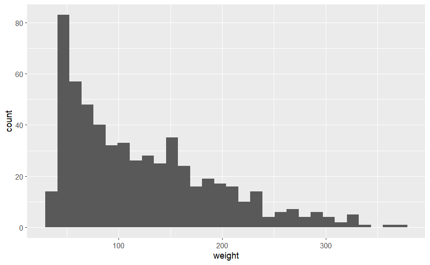

```r
head =(ChickWeight)
ChickWeight %>%
  ggplot(aes(x = weight)) + #provide the aes(aesthetic mapping, in this case, x-axis only)
geom_histogram()
```

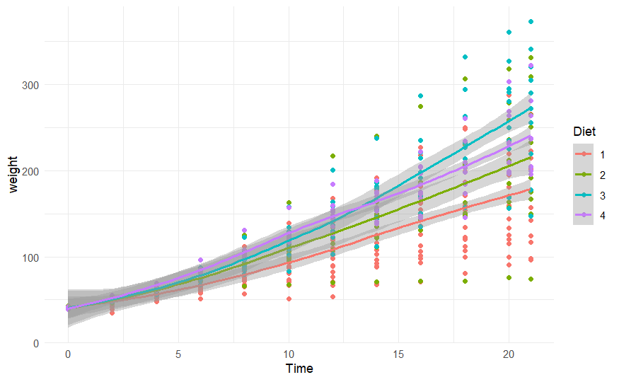

```r
head =(ChickWeight)
ChickWeight %>%
  ggplot(aes(y = weight,
             x = Time,
             color = Diet)) +
  geom_point() +
  geom_smooth() +
#creates function of best fit
# to remove the error bands, write the following = geom_smooth(se = FALSE)
theme_minimal()
```

#ICMA Oct 7 2024

```r
as.numeric("12")
```

```
[1] 12
```

```r
#only parses digits, words do not count, but numbers as chars work tho.
```

We can use is.numeric -> aka is.TYPE() in order to do a check to see i she is wo she is. Doubles are r’s default type of numeric. “as.integer()” forces a type to become an integer. To check type, we can do typeof(), to get the type directly.

```r
as.integer(12.3)
```

```
[1] 12
```

True = 1 False = 0

TRY on your own activity

```r
3 < 5 | FALSE
```

```
[1] TRUE
```

```r
#true
```

```r
is.numeric(mean(c(12,31,15.57,4)))
```

```
[1] TRUE
```

```r
#true 2nd
```

```r
((1+2)< -1000) | (TRUE | NA)
```

```
[1] TRUE
```

#ICMA Oct 9 2024 Data Structures : lists to get elements *you can do a list of vectors, and then go 2 brackets deeper to choose an element of that list

```r
my_list <- list(c("p","o","w","e","r"))
the_vector <- my_list[[1]][3]
the_vector
```

```
[1] "w"
```

Tibbles

treat like a data frame (table thingie) *tribble for “row-wise” declaration

```r
new_tibble_columnwise <- tibble( x  = 1:5 , y=1, z = x^2 + y)
new_tibble_columnwise
```

| x | y | z |
| --- | --- | --- |
| 1 | 1 | 2 |
| 2 | 1 | 5 |
| 3 | 1 | 10 |
| 4 | 1 | 17 |
| 5 | 1 | 26 |

Combining Data : diff vars - use join left_join vs right_join

left join -> joiner gets added to og, but only to stuff that they share in common with og (columnwise) right join -> joiner becomes the joinee, and joiner values are matched to og.

full join -> combines everybody

inner join -> venn diagram of rows that match

```r
age_data <- tribble(
                     ~id, ~age,
                     1,8,
                     2,10,
                     3,8,
                     5,9

              )

gender_data <- tribble (
                        ~id, ~ gender,
                        1,"f",
                        2,"m",
                        3,"nb",
                        4,"m",
                        6,"f",
              )
```

```r
age_data
```

| id | age |
| --- | --- |
| 1 | 8 |
| 2 | 10 |
| 3 | 8 |
| 5 | 9 |

```r
gender_data
```

| id | gender |
| --- | --- |
| 1 | f |
| 2 | m |
| 3 | nb |
| 4 | m |
| 6 | f |

```r
full_join(age_data, gender_data)
```

| id | age | gender |
| --- | --- | --- |
| 1 | 8 | f |
| 2 | 10 | m |
| 3 | 8 | nb |
| 5 | 9 | NA |
| 4 | NA | m |
| 6 | NA | f |

intersect is different from inner join intersect = a set operation -> this means that interesct worls if the data in in two different sets are the same there is also : union, (rows that appear in ether or both y and z) setdiff(rows that appear in y but not in z)

bind_rows() bindcols() -> both assumes that everything is in the same order.(APPEND)

#ICMA Oct 16 2024

```r
# for loops ( and iteration in R)
#you should write
#for (var in seq){
  #expr
#}
#for if statements, the if/elseif are the same syntax as java
```

#ICMA Oct 30 2024

```r
#Where would you find the YAML header ( top of the file (YAML aint markup language)) "header info"
#plain text( no frills, no bolding (which is what rich text is))

#what is knitting?
#sends rmd -> md
```